# PC2 - Minería de Datos

Histograma de variable “Volume” transformada (utilizando logaritmo):

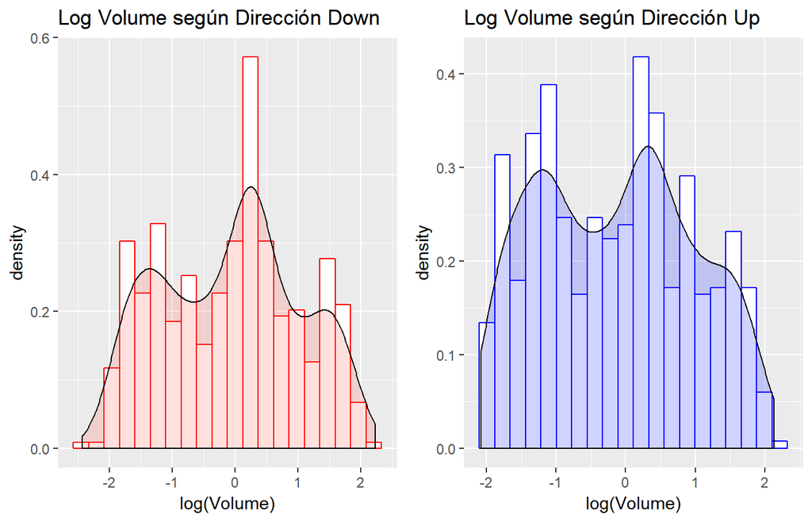

```r
library(dplyr)
x7.down=Weekly %>%
  filter(Direction=="Down") %>%
  ggplot(aes(log(Volume))) +
  geom_histogram(aes(y=..density..), bins = 20, colour="red", fill="white")+
  geom_density(alpha=0.2, fill="#FF6655",position = "stack")+
  ggtitle("Log Volume según Dirección Down")

x7.up=Weekly %>%
  filter (Direction=="Up")%>%
  ggplot(aes(log(Volume))) +
  geom_histogram(aes(y=..density..), bins = 20, colour="blue", fill="white")+
  geom_density(alpha=0.2, fill="#141CFF",position = "stack")+
  ggtitle("Log Volume según Dirección Up")

ggarrange(x7.down,x7.up, nrow = 1, ncol = 2)
```

Modelo con variable transformada:

```r
modelo <- glm(Direction ~ Lag1 + Lag2 + Lag3 + Lag4 + Lag5 + log(Volume), data = Weekly, family = "binomial")
summary(modelo)
```

```
##
## Call:
## glm(formula = Direction ~ Lag1 + Lag2 + Lag3 + Lag4 + Lag5 +
##     log(Volume), family = "binomial", data = Weekly)
##
## Deviance Residuals:
##     Min       1Q   Median       3Q      Max
## -1.6922  -1.2600   0.9928   1.0847   1.4665
##
## Coefficients:
##             Estimate Std. Error z value Pr(>|z|)
## (Intercept)  0.22562    0.06224   3.625 0.000289 ***
## Lag1        -0.04127    0.02637  -1.565 0.117578
## Lag2         0.05834    0.02679   2.178 0.029433 *
## Lag3        -0.01607    0.02663  -0.603 0.546213
## Lag4        -0.02790    0.02643  -1.055 0.291218
## Lag5        -0.01457    0.02636  -0.553 0.580433
## log(Volume) -0.05133    0.05607  -0.915 0.359988
## ---
## Signif. codes:  0 '***' 0.001 '**' 0.01 '*' 0.05 '.' 0.1 ' ' 1
##
## (Dispersion parameter for binomial family taken to be 1)
##
##     Null deviance: 1496.2  on 1088  degrees of freedom
## Residual deviance: 1485.9  on 1082  degrees of freedom
## AIC: 1499.9
##
## Number of Fisher Scoring iterations: 4
```

```r
# Se realizan las predicciones para el set de datos no empleado en la creación
# del modelo
predicciones2 <- predict(object = modelo, newdata = test_data, type = "response")
# Se considera como threshold de clasificación el 0.5
predicciones2[predicciones2 > 0.5] <- "Up"
predicciones2[predicciones2 != "Up"] <- "Down"
```

Matriz de confusión de modelo con variable transformada:

```r
table(clase_predicha = predicciones2, clase_real = test_data$Direction)
```

```
##               clase_real
## clase_predicha Down Up
##           Down   17 16
##           Up     26 45
```

Indicadores de Acurracy y test de error:

```r
# % de aciertos
paste("El % de acierto de predicción del modelo es",  mean(predicciones2 == test_data$Direction), "similar a los otros resultados")
```

```
## [1] "El % de acierto de predicción del modelo es 0.596153846153846 similar a los otros resultados"
```

```r
# % de errores
paste("El % de error de predicción del modelo es",mean(predicciones2 != test_data$Direction),  "similar a los otros resultados")
```

```
## [1] "El % de error de predicción del modelo es 0.403846153846154 similar a los otros resultados"
```

En el siguiente cuadro se observa un resumen de los resultados de la capacidad de predecir aciertos y errores de los diferentes modelos los cuales no muestran un buen desempeño. El modelo knn con interacción presenta mejores resulados para los aciertos y QDA con interacción es el que más porcentaje de error presenta.

```r
# consolidado


a.01<-mean(prediccon.inter.glm == test_data$Direction)
e.01<-mean(prediccon.inter.glm != test_data$Direction)
# Modelo Logístico con interacción
a.1<-cbind(a.01,e.01)

a.02<-mean(predicciones_lda$class == test_data$Direction)
e.02<-mean(predicciones_lda$class != test_data$Direction)
# Modelo LDA con interacción
a.2<-cbind(a.02,e.02)

a.03<-mean(predicciones_qda$class == test_data$Direction)
e.03<-mean(predicciones_qda$class != test_data$Direction)
# Modelo QDA con interacción
a.3<-cbind(a.03,e.03)

a.04<-mean(prediccion_knn2 == test_data$Direction)
e.04<-mean(prediccion_knn2 != test_data$Direction)
# Modelo KNN con K=6 con interacciones
a.4<-cbind(a.04,e.04)


a.05<-mean(predicciones2 == test_data$Direction)
e.05<-mean(predicciones2 != test_data$Direction)
# Modelo logístico con transformación de variable “Volume”
a.5<-cbind(a.05,e.05)

b1<-rbind(a.1,a.2,a.3,a.4,a.5)
colnames(b1)<-c("% acierto","% error")
rownames(b1)<-c("log.con.interacción","lda.con.interacción","qda.con.interacción","knn.con.interacción","log.con.transf.variable")
b1
```

```
##                         % acierto   % error
## log.con.interacción     0.5769231 0.4230769
## lda.con.interacción     0.5769231 0.4230769
## qda.con.interacción     0.4615385 0.5384615
## knn.con.interacción     0.6057692 0.3942308
## log.con.transf.variable 0.5961538 0.4038462
```

# 2. En este problema, desarrolle un modelo para predecir si un automóvil dado obtiene un millaje de gasolina alto o bajo en función del conjunto de datos Auto del paquete ISLR.

## a. Cree una variable binaria, mpg01, que contenga un 1 si mpg contiene un valor por encima de su mediana, y un 0 si mpg contiene un valor por debajo de su mediana. Puede calcular la mediana utilizando la función median(). Tenga en cuenta que puede resultarle útil utilizar la función data.frame() para crear un único conjunto de datos que contenga tanto mpg01 como las otras variables de Auto.

```r
Auto <- data.table(Auto)
mediana.mpg <- median(Auto$mpg)
Auto[ , mpg1 := as.factor(ifelse(mpg > mediana.mpg, 1, 0))]
Auto[sample(1:nrow(Auto), 15), ]
```

```
##      mpg cylinders displacement horsepower weight acceleration year origin
##  1: 13.0         8          302        129   3169         12.0   75      1
##  2: 22.0         6          225        100   3233         15.4   76      1
##  3: 25.0         4          110         87   2672         17.5   70      2
##  4: 37.0         4           91         68   2025         18.2   82      3
##  5: 18.0         6          199         97   2774         15.5   70      1
##  6: 20.2         8          302        139   3570         12.8   78      1
##  7: 25.0         4          140         92   2572         14.9   76      1
##  8: 34.1         4           91         68   1985         16.0   81      3
##  9: 30.7         6          145         76   3160         19.6   81      2
## 10: 32.0         4          144         96   2665         13.9   82      3
## 11: 27.0         4          101         83   2202         15.3   76      2
## 12: 19.0         6          225         95   3264         16.0   75      1
## 13: 18.1         6          258        120   3410         15.1   78      1
## 14: 26.0         4          122         80   2451         16.5   74      1
```

[output cut: 17 more lines]

## b. Explore los datos gráficamente para investigar la asociación entre mpg01 y las otras características. ¿Cuál de las otras características parece ser más útil para predecir mpg01? Los diagramas de dispersión y los diagramas de caja pueden ser herramientas útiles para responder a esta pregunta. Describe tus hallazgos.

- Matriz de correlación

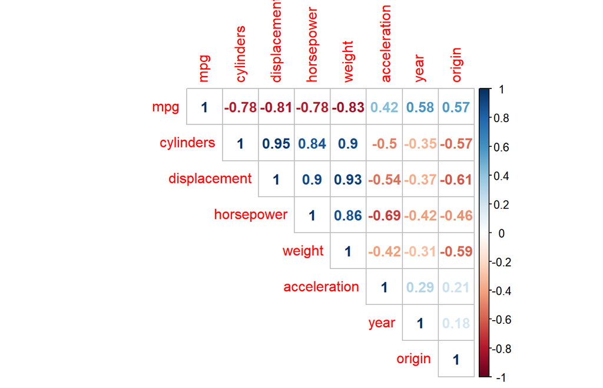

```r
M <- cor(Auto[ , -c(9, 10)])
corrplot(M, method = "number", type = "upper")
```

En la gráfica de matriz de correlación se observa una alta correlación negativa entre las variables “cylinders”, “displacement”, “horsepower” y “weight” con la variable “mpg”, que a su vez representa a la variable binaria de respuesta “mpg1”, es decir, todas estas variables al tener una relación lineal negativa podrían ayudar a predecir a “mpg1”; sin embargo, estas variables tienen una alta correlación positiva entre si, por lo cual antes de ingresar al modelo nos tocará elegir una de ellas para el modelamiento.

Para analizar y elegir a la(s) mejor(es) variable(s) que ayuden a predecir “mpg1”, teniendo en cuenta sus correlaciones, utilizaremos digramas de dispersión, de cajas y gráficos de desensidad.

- Diagramas de dispersión

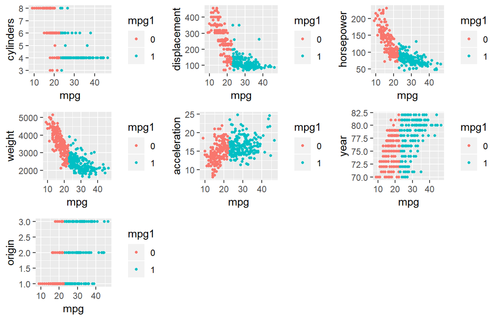

```r
p1=Auto %>%
  ggplot(aes(mpg, cylinders, colour = mpg1)) +
  geom_point(size = 1) +
  labs(x = "mpg", y = "cylinders")

p2=Auto %>%
  ggplot(aes(mpg, displacement, colour = mpg1)) +
  geom_point(size = 1) +
  labs(x = "mpg", y = "displacement")

p3=Auto %>%
  ggplot(aes(mpg, horsepower, colour = mpg1)) +
  geom_point(size = 1) +
  labs(x = "mpg", y = "horsepower")

p4=Auto %>%
  ggplot(aes(mpg, weight, colour = mpg1)) +
  geom_point(size = 1) +
  labs(x = "mpg", y = "weight")

p5=Auto %>%
  ggplot(aes(mpg, acceleration, colour = mpg1)) +
  geom_point(size = 1) +
  labs(x = "mpg", y = "acceleration")

p6=Auto %>%
  ggplot(aes(mpg, year, colour = mpg1)) +
  geom_point(size = 1) +
  labs(x = "mpg", y = "year")

p7=Auto %>%
  ggplot(aes(mpg, origin, colour = mpg1)) +
  geom_point(size = 1) +
  labs(x = "mpg", y = "origin")

ggarrange(p1,p2,p3,p4,p5,p6,p7, nrow = 3, ncol = 3)
```

En los gráficos de dispersión se verifica visualmente las correlaciones entre “mpg1” con las variables “cylinder”,“displacement”,“horsepower”, “weight”, “year” y “origin”, además podemos observar que sólo las variables “displacemente”, “horsepower” y “weight” hay mayor diferencia entre las poblaciones de la variable binaria “mpg1”

- Diagramas de cajas

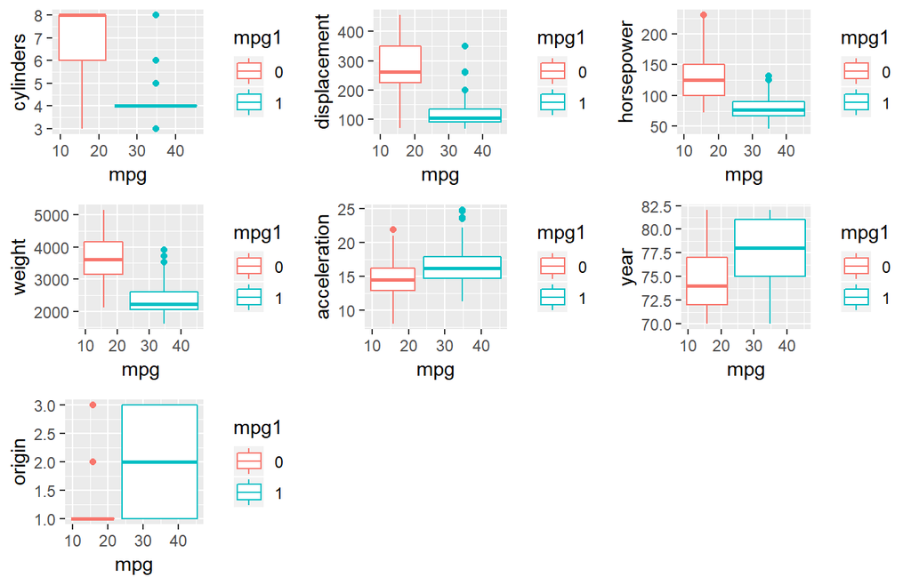

```r
p1=Auto %>%
  ggplot(aes(mpg, cylinders, colour = mpg1)) +
  geom_boxplot() +
  labs(x = "mpg", y = "cylinders")

p2=Auto %>%
  ggplot(aes(mpg, displacement, colour = mpg1)) +
  geom_boxplot() +
  labs(x = "mpg", y = "displacement")

p3=Auto %>%
  ggplot(aes(mpg, horsepower, colour = mpg1)) +
  geom_boxplot() +
  labs(x = "mpg", y = "horsepower")

p4=Auto %>%
  ggplot(aes(mpg, weight, colour = mpg1)) +
  geom_boxplot() +
  labs(x = "mpg", y = "weight")

p5=Auto %>%
  ggplot(aes(mpg, acceleration, colour = mpg1)) +
  geom_boxplot() +
  labs(x = "mpg", y = "acceleration")

p6=Auto %>%
  ggplot(aes(mpg, year, colour = mpg1)) +
  geom_boxplot() +
  labs(x = "mpg", y = "year")

p7=Auto %>%
  ggplot(aes(mpg, origin, colour = mpg1)) +
  geom_boxplot() +
  labs(x = "mpg", y = "origin")

ggarrange(p1,p2,p3,p4,p5,p6,p7, nrow = 3, ncol = 3)
```

Lo observado en los diagramas de dispersión puede corroborarse en los diagramas de cajas, donde las medias más distantes entre poblaciones se encuentran en las variables “displacement”, “horsepower” y “weight”.

- Gráficos de densidad

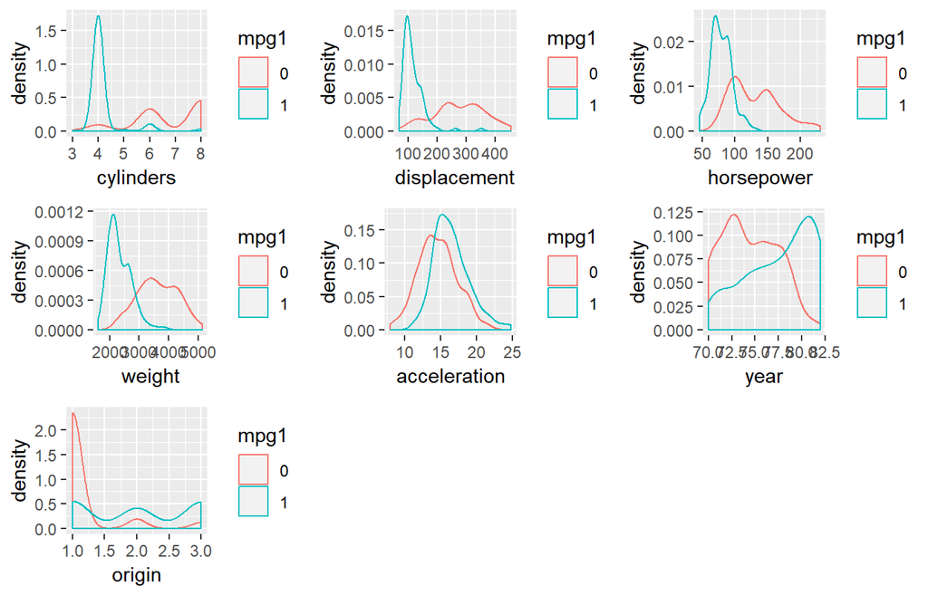

```r
p1=Auto %>%
  ggplot(aes(cylinders, colour = mpg1)) +
  geom_density()

p2=Auto %>%
  ggplot(aes(displacement, colour = mpg1)) +
  geom_density()

p3=Auto %>%
  ggplot(aes(horsepower, colour = mpg1)) +
  geom_density()

p4=Auto %>%
  ggplot(aes(weight, colour = mpg1)) +
  geom_density()

p5=Auto %>%
  ggplot(aes(acceleration, colour = mpg1)) +
  geom_density()

p6=Auto %>%
  ggplot(aes(year, colour = mpg1)) +
  geom_density()

p7=Auto %>%
  ggplot(aes(origin, colour = mpg1)) +
  geom_density()

ggarrange(p1,p2,p3,p4,p5,p6,p7, nrow = 3, ncol = 3)
```

Adicionalmente se ha visto necesario añadir gráficos de densidad para verificar los digramas de dispersión y cajas. Por tanto, eligiremos la variable “weight” por tener mayor distancia entre las medias de la variable binaria “mpg1” y se descartan las variables “displacement” y “horsepower” por multicolinealidad. Adicionalmente probaremos en los modelos con las variables “cylinders”,“year” y “origin”.

## c. Divida los datos en un conjunto de entrenamiento y un conjunto de prueba.

Se ha decidido dividir la data en 70% train y 30% test, realizando un muestreo estratificado por la variable de respuesta “mpg1” para asegurarnos la proporcionalidad del target en cada data creada.

```r
library(caret)
set.seed(604)
train.index <- createDataPartition(Auto$mpg1, p = .7, list = FALSE)
train <- Auto[ train.index,]
test  <- Auto[-train.index,]

prop.table(table(Auto$mpg1))
```

```
##
##   0   1
## 0.5 0.5
```

```r
prop.table(table(train$mpg1))
```

```
##
##   0   1
## 0.5 0.5
```

```r
prop.table(table(test$mpg1))
```

```
##
##   0   1
## 0.5 0.5
```

Como se observa la proporción del target en todas las datas (total, trains y test) es igual, lo cual asegura una estabilidad en el modelamiento. Por otro lado, para la data train quedaron 276 observaciones y para data test 116 observaciones:

```r
dim(train)[1]
```

```
## [1] 276
```

```r
dim(test)[1]
```

```
## [1] 116
```

## d. Realice LDA en los datos de entrenamiento para predecir mpg01 usando las variables que parecían más asociada con mpg01 en (b). ¿Cuál es el error de prueba (test error) del modelo obtenido?

```r
modelo_lda <- lda(mpg1 ~ cylinders+weight+year+origin, data = train)
modelo_lda
```

```
## Call:
## lda(mpg1 ~ cylinders + weight + year + origin, data = train)
##
## Prior probabilities of groups:
##   0   1
## 0.5 0.5
##
## Group means:
##   cylinders   weight     year   origin
## 0  6.804348 3644.862 74.47826 1.152174
## 1  4.224638 2337.232 77.54348 1.978261
##
## Coefficients of linear discriminants:
##                     LD1
## cylinders -0.3836017584
## weight    -0.0008748325
## year       0.1070639806
## origin     0.2654464642
```

```r
predicciones_train_lda <- predict(object = modelo_lda, train)
predicciones_test_lda <- predict(object = modelo_lda, test)
```

- Matriz de confusión en data test

```r
table(clase_real =  test$mpg1,clase_predicha = predicciones_test_lda$class)
```

```
##           clase_predicha
## clase_real  0  1
##          0 49  9
##          1  0 58
```

- Test de error de modelo LDA en el train y test respectivamente:

```r
paste("El % de error del modelo en train es:", mean(predicciones_train_lda$class != train$mpg1))
```

```
## [1] "El % de error del modelo en train es: 0.0942028985507246"
```

```r
paste("El % de error del modelo en test es:", mean(predicciones_test_lda$class != test$mpg1))
```

```
## [1] "El % de error del modelo en test es: 0.0775862068965517"
```

## e. Realice QDA en los datos de entrenamiento para predecir mpg01 usando las variables que parecían más asociadas con mpg01 en (b). ¿Cuál es el error de prueba del modelo obtenido?

```r
modelo_qda <- qda(mpg1 ~ cylinders + weight + year + origin, data = train)
modelo_qda
```

```
## Call:
## qda(mpg1 ~ cylinders + weight + year + origin, data = train)
##
## Prior probabilities of groups:
##   0   1
## 0.5 0.5
##
## Group means:
##   cylinders   weight     year   origin
## 0  6.804348 3644.862 74.47826 1.152174
## 1  4.224638 2337.232 77.54348 1.978261
```

```r
predicciones_train_qda <- predict(object = modelo_qda, train)
predicciones_test_qda <- predict(object = modelo_qda, test)
```

- Matriz de confusión en data test

```r
table(clase_real =  test$mpg1,clase_predicha = predicciones_test_qda$class)
```

```
##           clase_predicha
## clase_real  0  1
##          0 51  7
##          1  1 57
```

- Test de error de modelo QDA en el train y test respectivamente:

```r
paste("El % de error del modelo en train es:", mean(predicciones_train_qda$class != train$mpg1))
```

```
## [1] "El % de error del modelo en train es: 0.0905797101449275"
```

```r
paste("El % de error del modelo en test es:", mean(predicciones_test_qda$class != test$mpg1))
```

```
## [1] "El % de error del modelo en test es: 0.0689655172413793"
```

Los resultados son mejores a los presentados con el modelo LDA.

## f. Realice una regresión logística en los datos de entrenamiento para predecir mpg01 usando las variables que parecían más asociadas con mpg01 en (b). ¿Cuál es el error de prueba del modelo obtenido?

```r
modelo <- glm(mpg1 ~ cylinders + weight + year + origin, data = train, family = "binomial")
summary(modelo)
```

```
##
## Call:
## glm(formula = mpg1 ~ cylinders + weight + year + origin, family = "binomial",
##     data = train)
##
## Deviance Residuals:
##      Min        1Q    Median        3Q       Max
## -2.12534  -0.14114   0.01307   0.23896   2.95968
##
## Coefficients:
##               Estimate Std. Error z value Pr(>|z|)
## (Intercept) -2.009e+01  5.991e+00  -3.352 0.000801 ***
## cylinders   -2.918e-01  3.026e-01  -0.964 0.334849
## weight      -4.339e-03  8.792e-04  -4.934 8.04e-07 ***
## year         4.371e-01  8.903e-02   4.910 9.13e-07 ***
## origin       4.421e-01  3.469e-01   1.275 0.202443
## ---
## Signif. codes:  0 '***' 0.001 '**' 0.01 '*' 0.05 '.' 0.1 ' ' 1
##
## (Dispersion parameter for binomial family taken to be 1)
##
##     Null deviance: 382.62  on 275  degrees of freedom
## Residual deviance: 116.61  on 271  degrees of freedom
## AIC: 126.61
##
## Number of Fisher Scoring iterations: 7
```

```r
predicciones.test <- predict(object = modelo, newdata = test, type = "response")
predicciones.test[predicciones.test > 0.5] <- 1
predicciones.test[predicciones.test <= 0.5] <- 0
predicciones.test <- as.factor(predicciones.test)

predicciones.train <- predict(object = modelo, newdata = train, type = "response")
predicciones.train[predicciones.train > 0.5] <- 1
predicciones.train[predicciones.train <= 0.5] <- 0
predicciones.train <- as.factor(predicciones.train)
```

- Matriz de confusión en data test

```r
table(clase_predicha = predicciones.test, clase_real = test$mpg1)
```

```
##               clase_real
## clase_predicha  0  1
##              0 51  1
##              1  7 57
```

- Test de error de la regresión logística en el train y test respectivamente:

```r
paste("El % de error del modelo en train es:", mean(predicciones.train != train$mpg1))
```

```
## [1] "El % de error del modelo en train es: 0.0869565217391304"
```

```r
paste("El % de error del modelo en test es:", mean(predicciones.test != test$mpg1))
```

```
## [1] "El % de error del modelo en test es: 0.0689655172413793"
```

## g. Realice KNN en los datos de entrenamiento, con varios valores de K, para predecir mpg01. Use solo las variables que parecían más asociadas con mpg01 en (b). ¿Qué errores de prueba obtienes? ¿Qué valor de K parece tener el mejor rendimiento en este conjunto de datos?

- **Modelo Knn con K=3**

```r
#subsetting data set with desired variables
autoknn<-Auto[,c(2,5,7,8,10)]
#standardizing variables for knn
standardizedautoknn<-scale(autoknn[,-5])
#dividing in train and test data
train.index <- createDataPartition(Auto$mpg1, p = .7, list = FALSE)
autotrainknn = autoknn[train.index, ]
autotestknn = autoknn[-train.index, ]
library(class)
set.seed(123)
#KNN with k=3
knn.pred<-knn(autotrainknn[,-5],autotestknn[,-5],autotrainknn[,as.factor(mpg1)],k=3)
knn.pred.train<-knn(autotrainknn[,-5],autotrainknn[,-5],autotrainknn[,as.factor(mpg1)],k=3)
```

- Matriz de confusión de modelo KNN con K = 3

```r
table(clase_real = autotestknn$mpg1,clase_predicha = knn.pred)
```

```
##           clase_predicha
## clase_real  0  1
##          0 47 11
##          1 10 48
```

- Test de error de modelo KNN con K = 3 en el train y test respectivamente:

```r
paste("El % de error del modelo en train es:", mean(knn.pred.train != autotrainknn$mpg1))
```

```
## [1] "El % de error del modelo en train es: 0.072463768115942"
```

```r
paste("El % de error del modelo en test es:", mean(knn.pred != autotestknn$mpg1))
```

```
## [1] "El % de error del modelo en test es: 0.181034482758621"
```

El test de error del modelo KNN con K = 3 es mucho mayor al de los modelos desarrollados antes.

- **Modelo Knn con K=6**

```r
set.seed(123)
#KNN with k=50
knn.pred<-knn(autotrainknn[,-5],autotestknn[,-5],autotrainknn[,as.factor(mpg1)],k=6)
knn.pred.train<-knn(autotrainknn[,-5],autotrainknn[,-5],autotrainknn[,as.factor(mpg1)],k=6)
```

- Matriz de confusión de modelo KNN con K = 6

```r
table(clase_real = autotestknn$mpg1,clase_predicha = knn.pred)
```

```
##           clase_predicha
## clase_real  0  1
##          0 47 11
##          1 10 48
```

- Test de error de modelo KNN con K = 6 en el train y test respectivamente:

```r
paste("El % de error del modelo en train es:", mean(knn.pred.train != autotrainknn$mpg1))
```

```
## [1] "El % de error del modelo en train es: 0.0869565217391304"
```

```r
paste("El % de error del modelo en test es:", mean(knn.pred != autotestknn$mpg1))
```

```
## [1] "El % de error del modelo en test es: 0.181034482758621"
```

# 3. Utilizando el conjunto de datos de Boston del paquete MASS, ajuste los modelos de clasificación para predecir la tasa de delincuencia en los suburbios de Boston que esté por encima o por debajo de la mediana. Explore los modelos de regresión logística, LDA y KNN usando varios subconjuntos de predictores. Describe sus hallazgos.

Al igual que en el problema 2, comenzamos importando los datos y creando la variable binaria que será nuestra variable respuesta a predecir.

```r
Boston <- data.table(Boston)
mediana.crime <- median(Boston$crim)
Boston[ , indice := as.factor(ifelse(crim > mediana.crime, 1, 0))]
Boston[sample(1:nrow(Boston), 15),]
```

```
##         crim zn indus chas   nox    rm   age    dis rad tax ptratio  black
##  1:  0.06899  0 25.65    0 0.581 5.870  69.7 2.2577   2 188    19.1 389.15
##  2:  0.17505  0  5.96    0 0.499 5.966  30.2 3.8473   5 279    19.2 393.43
##  3:  0.15038  0 25.65    0 0.581 5.856  97.0 1.9444   2 188    19.1 370.31
##  4:  4.89822  0 18.10    0 0.631 4.970 100.0 1.3325  24 666    20.2 375.52
##  5: 15.86030  0 18.10    0 0.679 5.896  95.4 1.9096  24 666    20.2   7.68
##  6:  0.19073 22  5.86    0 0.431 6.718  17.5 7.8265   7 330    19.1 393.74
##  7:  0.02187 60  2.93    0 0.401 6.800   9.9 6.2196   1 265    15.6 393.37
##  8:  0.09299  0 25.65    0 0.581 5.961  92.9 2.0869   2 188    19.1 378.09
##  9:  0.01311 90  1.22    0 0.403 7.249  21.9 8.6966   5 226    17.9 395.93
## 10:  0.17783  0  9.69    0 0.585 5.569  73.5 2.3999   6 391    19.2 395.77
## 11:  0.01501 90  1.21    1 0.401 7.923  24.8 5.8850   1 198    13.6 395.52
## 12:  0.13117  0  8.56    0 0.520 6.127  85.2 2.1224   5 384    20.9 387.69
## 13:  0.11425  0 13.89    1 0.550 6.373  92.4 3.3633   5 276    16.4 393.74
## 14:  0.27957  0  9.69    0 0.585 5.926  42.6 2.3817   6 391    19.2 396.90
```

[output cut: 17 more lines]

En este problema también se ha decidido dividir la data en 70% train y 30% test, realizando un muestreo estratificado por la variable de respuesta “indice”, que proviene de la variable “crim”, para asegurarnos la proporcionalidad del target en cada data creada.

```r
library(caret)
set.seed(604)
train.index <- createDataPartition(Boston$indice, p = .7, list = FALSE)
train <- Boston[ train.index,]
test  <- Boston[-train.index,]

prop.table(table(Boston$indice))
```

```
##
##   0   1
## 0.5 0.5
```

```r
prop.table(table(Boston$indice))
```

```
##
##   0   1
## 0.5 0.5
```

```r
prop.table(table(Boston$indice))
```

```
##
##   0   1
## 0.5 0.5
```

```r
dim(train)[1]
```

```
## [1] 356
```

```r
dim(test)[1]
```

```
## [1] 150
```

- **Modelo logístico**

Creamos un modelo tradicional y otro haciendo stepwise minimizando el AIC del modelo.

```r
fit.logit <- glm(indice ~ zn + indus + chas + nox + rm +age + dis + rad + tax + ptratio + black +lstat + medv, data = train, family = "binomial")
fit.logit.2 <- stepAIC(fit.logit, trace = FALSE)
summary(fit.logit.2)
```

```
##
## Call:
## glm(formula = indice ~ zn + nox + age + dis + rad + tax + ptratio +
##     medv, family = "binomial", data = train)
##
## Deviance Residuals:
##     Min       1Q   Median       3Q      Max
## -1.7998  -0.1674  -0.0003   0.0030   3.5860
##
## Coefficients:
##               Estimate Std. Error z value Pr(>|z|)
## (Intercept) -39.742748   7.236324  -5.492 3.97e-08 ***
## zn           -0.089316   0.039143  -2.282 0.022504 *
## nox          46.711887   8.080875   5.781 7.45e-09 ***
## age           0.037507   0.012605   2.976 0.002924 **
## dis           0.749350   0.250126   2.996 0.002736 **
## rad           0.733152   0.177258   4.136 3.53e-05 ***
## tax          -0.008676   0.003238  -2.680 0.007373 **
## ptratio       0.285937   0.127295   2.246 0.024688 *
## medv          0.139606   0.042146   3.312 0.000925 ***
## ---
## Signif. codes:  0 '***' 0.001 '**' 0.01 '*' 0.05 '.' 0.1 ' ' 1
##
## (Dispersion parameter for binomial family taken to be 1)
##
##     Null deviance: 493.52  on 355  degrees of freedom
## Residual deviance: 150.81  on 347  degrees of freedom
## AIC: 168.81
##
## Number of Fisher Scoring iterations: 9
```

```r
modelo<- glm(indice ~ zn + nox+ rad + tax + ptratio + black + medv, data = train,family = "binomial")
summary(modelo)
```

```
##
## Call:
## glm(formula = indice ~ zn + nox + rad + tax + ptratio + black +
##     medv, family = "binomial", data = train)
##
## Deviance Residuals:
##      Min        1Q    Median        3Q       Max
## -2.01548  -0.19894  -0.00113   0.00416   2.93661
##
## Coefficients:
##               Estimate Std. Error z value Pr(>|z|)
## (Intercept) -24.205046   5.370694  -4.507 6.58e-06 ***
## zn           -0.048869   0.029655  -1.648  0.09937 .
## nox          37.221734   6.041691   6.161 7.24e-10 ***
## rad           0.685591   0.163260   4.199 2.68e-05 ***
## tax          -0.009632   0.003071  -3.137  0.00171 **
## ptratio       0.254806   0.123281   2.067  0.03875 *
## black        -0.006653   0.005283  -1.259  0.20787
## medv          0.073502   0.032776   2.243  0.02492 *
## ---
## Signif. codes:  0 '***' 0.001 '**' 0.01 '*' 0.05 '.' 0.1 ' ' 1
##
## (Dispersion parameter for binomial family taken to be 1)
##
##     Null deviance: 493.52  on 355  degrees of freedom
## Residual deviance: 163.34  on 348  degrees of freedom
## AIC: 179.34
##
## Number of Fisher Scoring iterations: 9
```

Matriz de confusión del modelo logístico:

```r
predicciones2 <- predict(object = modelo, newdata = test, type = "response")

# Se considera como threshold de clasificación el 0.5
predicciones2[predicciones2 > 0.5] <- 1
predicciones2[predicciones2 <= 0.5] <- 0
predicciones2 <- as.factor(predicciones2)

table(clase_real = test$indice,clase_predicha = predicciones2)
```

```
##           clase_predicha
## clase_real  0  1
##          0 67  8
##          1 11 64
```

Indicadores de Accuracy y error:

```r
# % de aciertos
paste("% de acierto:", mean(predicciones2 == test$indice))
```

```
## [1] "% de acierto: 0.873333333333333"
```

```r
# % de errores
paste("% de error:", mean(predicciones2 != test$indice))
```

```
## [1] "% de error: 0.126666666666667"
```

- **Modelo LDA**

```r
#lda
modelo_lda <- lda(indice ~ zn + nox + dis + rad + tax + ptratio + black + medv, data = train)
modelo_lda
```

```
## Call:
## lda(indice ~ zn + nox + dis + rad + tax + ptratio + black + medv,
##     data = train)
##
## Prior probabilities of groups:
##   0   1
## 0.5 0.5
##
## Group means:
##          zn       nox      dis       rad      tax  ptratio    black
## 0 20.578652 0.4727197 4.976615  4.162921 310.6011 18.01067 387.6602
## 1  1.247191 0.6369326 2.479188 14.966292 509.5899 18.94719 325.9025
##       medv
## 0 24.72753
## 1 20.61292
##
## Coefficients of linear discriminants:
##                   LD1
## zn      -0.0081013439
## nox      9.5120071406
## dis     -0.0368016155
## rad      0.0873856680
## tax     -0.0013769784
## ptratio  0.0224916201
## black   -0.0009638113
## medv     0.0348565185
```

Matriz de confusión del modelo LDA:

```r
predicciones_lda <- predict(object = modelo_lda, test)
table(clase_real =  test$indice,clase_predicha = predicciones_lda$class)
```

```
##           clase_predicha
## clase_real  0  1
##          0 74  1
##          1 16 59
```

Indicadores de Accuracy y error:

```r
# % de aciertos
paste("% de acierto:", mean(predicciones_lda$class == test$indice))
```

```
## [1] "% de acierto: 0.886666666666667"
```

```r
# % de errores
paste("% de error:", mean(predicciones_lda$class != test$indice))
```

```
## [1] "% de error: 0.113333333333333"
```

- **Modelo Knn, con K = 1**

```r
#KNN k=1
set.seed(604)
prediccion_knn2 <- knn(train = train[,c("zn","nox","dis","rad","tax","ptratio","black","medv")],
                       test = test[,c("zn","nox","dis","rad","tax","ptratio","black","medv")] ,
                       cl = train[["indice"]], k = 1)
```

Matriz de confusión del modelo Knn con K=1:

```r
table(clase_real = test$indice,clase_predicha = prediccion_knn2)
```

```
##           clase_predicha
## clase_real  0  1
##          0 71  4
##          1  4 71
```

Indicadores de Accuracy y error:

```r
# % de aciertos
paste("% de acierto:", mean(prediccion_knn2 == test$indice))
```

```
## [1] "% de acierto: 0.946666666666667"
```

```r
# % de errores
paste("% de error:", mean(prediccion_knn2 != test$indice))
```

```
## [1] "% de error: 0.0533333333333333"
```

- **Modelo Knn, con K = 3**

```r
set.seed(604)
prediccion_knn3 <- knn(train = train[,c("zn","nox","dis","rad","tax","ptratio","black","medv")],
                       test = test[,c("zn","nox","dis","rad","tax","ptratio","black","medv")] ,
                       cl = train[["indice"]], k = 3)
```

Matriz de confusión del modelo Knn con K = 3:

```r
table(clase_real = test$indice,clase_predicha = prediccion_knn3)
```

```
##           clase_predicha
## clase_real  0  1
##          0 70  5
##          1  4 71
```

Indicadores de Accuracy y error:

```r
# % de aciertos
paste("% de acierto:", mean(prediccion_knn3 == test$indice))
```

```
## [1] "% de acierto: 0.94"
```

```r
# % de errores
paste("% de error:", mean(prediccion_knn3 != test$indice))
```

```
## [1] "% de error: 0.06"
```

Finalmente el modelo con mayor porcentaje de aciertos y por ende menor error de clasificación es el KNN con K = 1.